# PSTAT 131 Final Project

# 1. Introduction

## 1.1 Project Overview

In today's competitive business environment, understanding customer behavior is critical for driving effective marketing strategies and fostering customer loyalty, especially as data becomes increasingly readily available. This project focuses on customer segmentation using RFM (Recency, Frequency, Monetary) analysis, a method that evaluates customer behavior based on transactional data. By clustering customers based on these metrics, the project aims to identify distinct customer segments that can inform targeted marketing strategies, improve customer retention, and optimize resource allocation, ultimately enhancing business decision-making.

**What is Customer Segmentation?**

Customer segmentation is the process of dividing a company's customer base into distinct groups that share similar characteristics. These characteristics can include purchasing behavior, preferences, and other relevant factors. The goal of customer segmentation is to better understand the needs and behaviors of different customer groups, allowing businesses to tailor their marketing efforts, improve customer satisfaction, and ultimately drive sales. In this project, customer segmentation is achieved through clustering techniques applied to RFM metrics, which provide a clear picture of customer behavior based on transactional data.

## 1.2 Problem Formulation: RFM Analysis

### Reasoning and Formulas

**What is RFM and why is it useful?**

The dataset available for this project is limited, containing only transactional information such as timestamps, quantities purchased, and unit prices, with no demographic or additional customer information. Given these constraints, RFM analysis was chosen as the most effective approach to segment customers. RFM stands for Recency, Frequency, and Monetary, and it is a method in marketing and customer analytics to evaluate and segment customers based on their purchasing behavior: how recently a customer has made a purchase (Recency), how often they purchase (Frequency), and how much they spend (Monetary).

**Formulas and Descriptions**

Recency (R): Measures how recently a customer made a purchase. Customers who have purchased recently are more updated with and responsive to new offers compared to those who haven't purchased in a long time.

- Recency = (Most Recent Date in Dataset) − (Last Purchase Date of Customer)

Frequency (F): Measures how often a customer makes a purchase. Customers who purchase frequently are more engaged and loyal.

- Frequency = Total Number of Days Where Customer Made a Purchase

Monetary (M): Measures how much money a customer spends. High monetary value customers are typically the most valuable to a business.

- Monetary Sum of (Quantity) × (Unit Price for All Transactions)

These three metrics are calculated for each customer and then used to create RFM scores, which are later scaled and used for clustering.

## 1.3 Dataset Description

We are using the **Online Retail** dataset, which contains transactional data from a UK based online retailer that primarily sells gifts for various occasions. The company is fairly small, with only around 80 employees when the study was published in 2012. The dataset spans from December 2010 to December 2011, and includes the following variables:

| Variable Name | Role | Type | Description | Units |
| --- | --- | --- | --- | --- |
| InvoiceNo | ID | Categorical | a 6-digit integral number uniquely assigned to each transaction. If this code starts with letter 'c', it indicates a cancellation |  |
| StockCode | ID | Categorical | a 5-digit integral number uniquely assigned to each distinct product |  |
| Description | Feature | Categorical | product name |  |
| Quantity | Feature | Integer | the quantities of each product (item) per transaction |  |
| InvoiceDate | Feature | Date | the day and time when each transaction was generated |  |
| UnitPrice | Feature | Continuous | product price per unit | sterling |
| CustomerID | Feature | Categorical | a 5-digit integral number uniquely assigned to each customer |  |
| Country | Feature | Categorical | the name of the country where each customer resides |  |

**Dataset Link:** https://archive.ics.uci.edu/dataset/352/online+retail

# 2. Exploratory Data Analysis

## 2.1 Data Exploration and Cleaning

The dataset was provided in the form of an Excel file, which we downloaded and converted into a Pandas DataFrame.

```python
# Load Libraries and Data
import pandas as pd
import numpy as np
from google.colab import drive

pd.options.mode.copy_on_write = True
drive.mount('/content/drive')

df = pd.read_excel('/content/drive/MyDrive/Winter 2025 Courses/PSTAT 131/Final Project/Online Retail.xlsx')
df.head()
```

|  | InvoiceNo | StockCode | Description | Quantity | InvoiceDate | UnitPrice | CustomerID | Country |
| --- | --- | --- | --- | --- | --- | --- | --- | --- |
| 0 | 536365 | 85123A | WHITE HANGING HEART T-LIGHT HOLDER | 6 | 2010-12-01 08:26:00 | 2.55 | 17850.0 | United Kingdom |
| 1 | 536365 | 71053 | WHITE METAL LANTERN | 6 | 2010-12-01 08:26:00 | 3.39 | 17850.0 | United Kingdom |
| 2 | 536365 | 84406B | CREAM CUPID HEARTS COAT HANGER | 8 | 2010-12-01 08:26:00 | 2.75 | 17850.0 | United Kingdom |
| 3 | 536365 | 84029G | KNITTED UNION FLAG HOT WATER BOTTLE | 6 | 2010-12-01 08:26:00 | 3.39 | 17850.0 | United Kingdom |
| 4 | 536365 | 84029E | RED WOOLLY HOTTIE WHITE HEART. | 6 | 2010-12-01 08:26:00 | 3.39 | 17850.0 | United Kingdom |

First, we looked for missing values in the data and decided how best to handle them. The only two columns that had any missing values were Description and CustomerID. For the purposes of our analysis, missing values for description were not actually relevant, because we aggregate individual products/purchases into totals for each customer and other information about the products like the StockCode, Price, and Quantity was still provided. Thus, we did not take any special action for rows where a product description was not given. However, it is clearly impossible to derive any meaningful information for customer segmentation for the invoices where there is no ID recorded to identify the customer. In the research paper that the dataset originated from, customers were only identified by address and post code, indicating that the CustomerID provided in the public dataset may be empty in cases where that information may not be uniquely identifying or available. Some observations with a missing customer ID also representing special transactions such as fees paid to Amazon and adjusting debt information. As such, we chose to simply exclude every row without a CustomerID from our analysis. Even though there were a total of 135,080 such observations, we still had over 400,000 remaining data points to use.

```python
# Number of NA Values in each column
print(df.isna().sum())
```

```
InvoiceNo           0
StockCode           0
Description      1454
Quantity            0
InvoiceDate         0
UnitPrice           0
CustomerID     135080
Country             0
dtype: int64
```

```python
# Handling Missing Values: Delete rows with NA CustomerID value

clean_df = df.dropna(subset=['CustomerID'])
```

### Other Notable Discoveries

While examining the dataset, we found a few interesting special cases. While the vast majority of the stock codes were 5-6 character numeric identifiers for products, some stock codes represented non-product payments/costs, such as postage or bank charges. Since these payments don't really represent money earned by the company, and instead are just various external fees paid by the customer, we decided to ignore them for the purpose of RFM Analysis. However, a few of these special Stock Codes were genuinely meaningful for our clustering. `M`, corresponding to Manual, was likely used to represent purchases where a correct stock code did not exist in the system and `D`, corresponding to Discount, was used to handle discounts when processing refunds.

In general, refunded orders were input as having the same invoice number as the original order, but with a preceding "C" and a negative quantity value. Since the quantity times unit price in a refund was the exact negative of the orginal purchase, we simply ignored the refunds and allowed two to cancel out when summing purchases. In some cases, the original orders did not exist, resulting in negative total customer spending, which we set to zero.

Many of the customers were not individuals, but instead organizational, such as wholesale businesses. This is clear from the fact that some customers spent hundreds of thousands of dollars, and on average, each order had 18.3 unique items.

```python
# Delete Rows with Irrelevant Stock Codes
# POST: Postage
# C2: Carriage
# BANK CHARGES: Bank Charges
# PADS: Pads to Match All Cushions
# DOT: DotCom Postage
# CRUK: CRUK(Cancer Research UK) Comission

bad_stock_codes = ['POST', 'C2', 'BANK CHARGES', 'PADS', 'DOT', 'CRUK']
clean_df = clean_df[~clean_df['StockCode'].isin(bad_stock_codes)]
```

### Outliers

After aggregating purchase data into per-customer totals, we found that some customers had hugely greater spending than others. Since these ultra-high spenders, even after some scaling, were extremely far from the other customer's Monetary values in the RFM axes, they threw off clustering and resulted in the vast majority of customers being clumped into just one or two groups. In order to get more meaningful clustering for the largest group of customers, we decided to exclude those who had spent over £5,000. From the actual business's perspective, they would likely have specific plans for or contact with their largest customers, rather than the more-broad RFM clusters. Only 263 customers, or around 6%, spent over £5,000. Note that this was done after the data transformation in the next section. There was also significantly high outliers for Frequency, the number of days a customer made purchases, but we felt that removing those would detract from the meaning of the RFM groups. For Monetary, it would make sense to say that a customer spending £20 is a low-spender and a customer spending £3,000 is a high-spender after removing the highest outliers, but it would make much less sense for Frequency to say that a customer making purchases on 4 days in the 1-year time span is far less frequent than a customer making purchases on 10 days.

## 2.2 Data Transformation for RFM

Next, we had to convert the data from the original format of the provided dataset into a suitable form for RFM customer segmentation clustering. First, we combined the individual spending per item into daily totals, with columns `CustomerID`, `Timestamp`, and `Total`.

```python
# RFM Encode
# Discard Hour and Minute
clean_df["Timestamp"] = pd.to_datetime(clean_df["InvoiceDate"], format="%m/%d/%Y %H:%M").dt.date
clean_df["Total"] = clean_df["Quantity"] * clean_df["UnitPrice"]
clean_df = clean_df[["CustomerID", "Total", "Timestamp"]]

clean_df = clean_df.groupby(["CustomerID", "Timestamp"]).agg("sum").reset_index()
clean_df.head(10)
```

|  | CustomerID | Timestamp | Total |
| --- | --- | --- | --- |
| 0 | 12346.0 | 2011-01-18 | 0.00 |
| 1 | 12347.0 | 2010-12-07 | 711.79 |
| 2 | 12347.0 | 2011-01-26 | 475.39 |
| 3 | 12347.0 | 2011-04-07 | 636.25 |
| 4 | 12347.0 | 2011-06-09 | 382.52 |
| 5 | 12347.0 | 2011-08-02 | 584.91 |
| 6 | 12347.0 | 2011-10-31 | 1294.32 |
| 7 | 12347.0 | 2011-12-07 | 224.82 |
| 8 | 12348.0 | 2010-12-16 | 652.80 |
| 9 | 12348.0 | 2011-01-25 | 187.44 |

Then, we converted the data into structures that matched our desired RFM information. Namely, Recency represented the number of days since a customer had last made a purchase (with 0 being the last day recorded in the dataset), Frequency represented the total number of days that a customer had bought things, and Monetary represented the total number of Pound Sterling spent.

```python
rfm_df = clean_df.groupby("CustomerID").agg({"Timestamp": "max", "Total": ["sum", "count"]})

# Recency
rfm_df["Recency"] = (rfm_df["Timestamp"]["max"].max() - rfm_df["Timestamp"]["max"]).apply(lambda x: x.days)

# Frequency
rfm_df["Frequency"] = rfm_df["Total"]["count"]

# Monetary
rfm_df["Monetary"] = rfm_df["Total"]["sum"]

rfm_df = rfm_df.drop(["Timestamp", "Total"], axis=1)
rfm_df.head()
```

| CustomerID | Recency | Frequency | Monetary |
| --- | --- | --- | --- |
| 12346.0 | 325 | 1 | 0.00 |
| 12347.0 | 2 | 7 | 4310.00 |
| 12348.0 | 75 | 4 | 1437.24 |
| 12349.0 | 18 | 1 | 1457.55 |
| 12350.0 | 310 | 1 | 294.40 |

```python
# Convert negative values of Monetary (More refunded than bought within the timespan)to zero
rfm_df["Monetary"] = rfm_df["Monetary"].apply(lambda x: 0 if x < 0 else x)

rfm_df_no_out = rfm_df[rfm_df["Monetary"] < 5000]

rfm_df_no_out.head()
```

| CustomerID | Recency | Frequency | Monetary |
| --- | --- | --- | --- |
| 12346.0 | 325 | 1 | 0.00 |
| 12347.0 | 2 | 7 | 4310.00 |
| 12348.0 | 75 | 4 | 1437.24 |
| 12349.0 | 18 | 1 | 1457.55 |
| 12350.0 | 310 | 1 | 294.40 |

Since the scales of the columns, particularly Monetary, were quite different from one another, we decided to scale the data. Since all of the values were non-negative, using a Max Absolute Scaler meant that for any column, a value of 0 represented the lowest possible value, and a value of 1 represented the highest observed value.

```python
# Scale RFM
from sklearn.preprocessing import MaxAbsScaler

scaler = MaxAbsScaler()
scaled_df = scaler.fit_transform(rfm_df_no_out)
```

## 2.3 Data Visualization

Histograms and Trends:

- Customers vs Recency: Show how recently customers made purchases.
- Customers vs Frequency: Show how often customers purchase.
- Customers vs Monetary: Show how much customers spend.
- Purchase vs Time: Highlight seasonal trends (e.g., spikes during holidays).

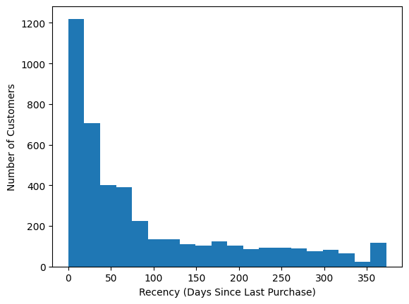

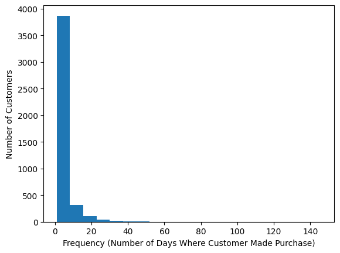

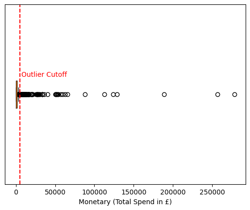

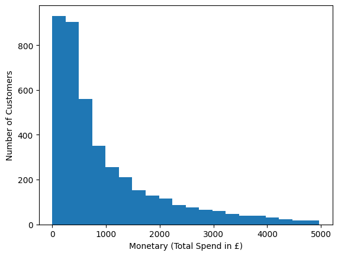

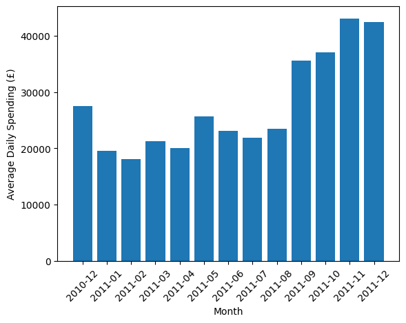

```python
import matplotlib.pyplot as plt
import numpy as np

# Histogram of Recency Value
plt.hist(rfm_df["Recency"], bins=20)
plt.xlabel("Recency (Days Since Last Purchase)")
plt.ylabel("Number of Customers")
plt.show()

# Histogram of Frequency Value
plt.hist(rfm_df["Frequency"], bins=20)
plt.xlabel("Frequency (Number of Days Where Customer Made Purchase)")
plt.ylabel("Number of Customers")
plt.show()

# Horizontal Box Plot of Monetary Value (Outliers Included)
plt.boxplot(rfm_df["Monetary"], vert=False)
plt.xlabel("Monetary (Total Spend in £)")
plt.yticks([])
plt.axvline(x=5000, color='r', linestyle='--')
plt.text(7000, 1.1, 'Outlier Cutoff', color='r')
plt.show()

# Histogram of Monetary Value (Outliers Removed)
plt.hist(rfm_df_no_out["Monetary"], bins=20)
plt.xlabel("Monetary (Total Spend in £)")
plt.ylabel("Number of Customers")
plt.show()


# Total Spending for Each Day
daily_spending = clean_df.groupby('Timestamp')['Total'].sum()

# Group by Month and find Average Daily Spending
daily_spending = daily_spending.reset_index()
daily_spending['Month'] = pd.to_datetime(daily_spending["Timestamp"]).dt.to_period('M')
monthly_avg_spending = daily_spending.groupby('Month')['Total'].mean()

# Bar Plot of Spending over Time
plt.bar(monthly_avg_spending.index.astype(str), monthly_avg_spending.values)
plt.xlabel('Month')
plt.ylabel('Average Daily Spending (£)')
plt.xticks(rotation=45)
plt.show()
```

# 3. Clustering Techniques

## 3.1 Hierarchical Clustering

Two clustering techniques were applied to the RFM data:

1. Hierarchical Clustering started from the bottom-up, with each customer in their own cluster, then combining the closest customers at each step. From there, we plotted a dendrogram to show how the clusters merged at different distances (Euclidean, average linkage) from each other. Since choosing any distance for a cutoff would be rather arbitrary, we tried different cutoff values to produce a reasonble number of clusters given the context. Although a lower cutoff would result in the customers in each cluster being more similar, this would not be feasible for the actual use-case. The company that the data comes from only had around 80 employees at the time, meaning there were likely only a few people involved with marketing and other customer interaction, so anything beyond 5-10 groups would be impractical and unmanagable.
2. K-Means Clustering started with an assignment of clusters, then iteratively reassigning points to the closest cluster centroid, until it converged. Although K-Means is often used with this initial assignment done randomly, we opted to use the default SciKit Learn option that performs "sampling based on an empirical probability distribution of the points’ contribution to the overall inertia". Choosing the K parameter was actually beneficial in our case, since we had limits on the number of clusters that would be legitimately useful and beneficial to consider. We chose K=5, as a good balance between having enough clusters for them to be distinct, but not so many that they could not be interpreted/used by a small team.

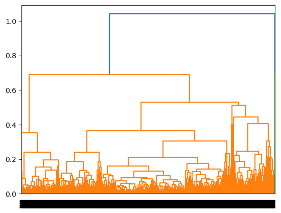

```python
from scipy.cluster.hierarchy import linkage, dendrogram
import matplotlib.pyplot as plt

linked = linkage(scaled_df, method="average")

# Hierarchical Clustering
dendrogram(linked)
plt.show()
```

```
6 Total Clusters Created

Cluster 1: 605
Cluster 2: 2803
Cluster 3: 29
Cluster 4: 674
Cluster 5: 1
Cluster 6: 1
```

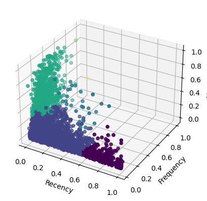

```python
from scipy.cluster.hierarchy import fcluster

clusters = fcluster(linked, 0.5, criterion='distance')

from mpl_toolkits.mplot3d import Axes3D
fig = plt.figure()
ax = fig.add_subplot(projection='3d')

ax.scatter(scaled_df[:,0], scaled_df[:,1], scaled_df[:,2], c=clusters)
ax.set_xlabel('Recency')
ax.set_ylabel('Frequency')
ax.set_zlabel('Monetary')

# Number of clusters
print(f"{len(np.unique(clusters))} Total Clusters Created\n")

from collections import Counter
cluster_counts_hier = Counter(clusters)
cluster_counts_hier = dict(sorted(cluster_counts_hier.items()))
for cluster, count in cluster_counts_hier.items():
    print(f"Cluster {cluster}: {count}")
```

## 3.2 K-Means Clustering

```
Cluster 0: 804
Cluster 1: 699
Cluster 2: 388
Cluster 3: 607
Cluster 4: 1615
```

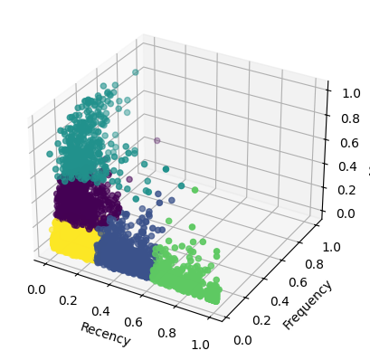

```python
# K Means Clustering
from sklearn.cluster import KMeans
import random
# K-Means not deterministic, so set seed
random.seed(42)

# Chose K=5 since it got closest to desired clustering results
kmeans = KMeans(n_clusters=5, random_state=0).fit(scaled_df)

# Get cluster assignments for each data point
labels = kmeans.labels_

cluster_counts_kmean = Counter(labels)
cluster_counts_kmean = dict(sorted(cluster_counts_kmean.items()))
for cluster, count in cluster_counts_kmean.items():
    print(f"Cluster {cluster}: {count}")

from mpl_toolkits.mplot3d import Axes3D
fig = plt.figure()
ax = fig.add_subplot(projection='3d')

ax.scatter(scaled_df[:,0], scaled_df[:,1], scaled_df[:,2], c=labels)
ax.set_xlabel('Recency')
ax.set_ylabel('Frequency')
ax.set_zlabel('Monetary')
plt.show()
```

## 3.3 Comparison of Clustering Methods

```python
from sklearn.metrics import silhouette_score

# Hierarchical
print(f"Hierarchical Clustering Silhouette Score: {round(silhouette_score(scaled_df, clusters), 4)}")
print("\nHierarchical Clusters:\n")
rfm_df_no_out["Cluster"] = clusters
cluster_df = rfm_df_no_out.groupby("Cluster").agg("mean")
cluster_df = cluster_df.sort_values(by='Cluster')
cluster_df["Size"] = cluster_counts_hier.values()
print(cluster_df.head(10).round(2))

# K Means
print(f"\nK-Means Clustering Silhouette Score: {round(silhouette_score(scaled_df, labels), 4)}")
print("\nK-Means Clusters:\n")
rfm_df_no_out["Cluster"] = labels
cluster_df = rfm_df_no_out.groupby("Cluster").agg("mean")
cluster_df = cluster_df.sort_values(by='Cluster')
cluster_sizes = cluster_counts_kmean.values()
cluster_df["Size"] = cluster_counts_kmean.values()
print(cluster_df.head(10).round(2))
```

```
Hierarchical Clustering Silhouette Score: 0.446

Hierarchical Clusters:

        Recency Frequency Monetary  Size

Cluster
1        297.50      1.32   308.03   605
2         70.08      2.66   654.29  2803
3        177.38      5.17  3182.92    29
4         21.18      8.25  2819.34   674
5         10.00     29.00  4640.77     1
6         21.00     35.00  1296.44     1

K-Means Clustering Silhouette Score: 0.4359

K-Means Clusters:

        Recency Frequency Monetary  Size

Cluster
0         32.30      5.59  1669.05   804
1        163.51      2.07   506.94   699
2         28.66      9.47  3454.24   388
3        297.80      1.35   333.87   607
4         39.46      2.22   482.75  1615
```

Note that the displayed Recency/Frequency/Monetary means for each cluster are not scaled, but the actual clustering was performed with maximum absolute scaling, meaning that the maximum possible value after scaling would be 1 for each column. Silhouette Score, a measure ranging from -1 to 1 of how similar observations are to others in their cluster compared to observations in other clusters, was similar for both clustering methods, at around 0.44. This indicates that the clusters for both methods were not particularly strong. However, looking at the actual clusters, K-Means performed far better than Hierarchical in terms of providing useful final groupings. In the Hierarchical clustering, the 3 smallest clusters make up just 31 customers, or about 0.7% of the total, with the largest cluster having almost 70%. Such unevenly distributed cluster sizes make actually utilizing the groups for marketing or outreach much more difficult, since groups are either too large to give specific information or too small to be worth the effort. K-means provides much more evenly sized clusters, with even the smallest having almost 400 customers. This was primarily due to the fact that the vast majority of customers did not make many purchases, with most making purchases on less than 10 days in the approximately 1 year timespan covered by the dataset. Hierarchical clustering separated some of the outliers with much greater Frequency into their own groups, but essentially sacrificed good clustering for Recency, Monetary, and the majority of the data points to do so. In comparison, K-Means still had a cluster with significantly higher frequency, but captured a much larger number of customers within that group. Since the numerical quality in terms within-cluster distance and between-cluster distance as measured by Silhouette Score is about the same for both methods, K-Means provided better-balanced/more useful clusters, and the K parameter allowed us to directly fix a desired number of clusters that would be reasonable for the use-case, K-Means was the better clustering algorithm for our analysis.

# 4. Summary of Analytical Results & Business Application

## 4.1 Summary of Our Analytical Process

This project responds to the challenge/task of customer segmentation, approaching from the angle of purchasing behavior rather than demographics (since customers are only identified by ID and Country) or interests (since minimal information is present about categories or other facts about specific products). We conducted RFM (Recency, Frequency, Monetary) analysis to evaluate customer behavior based on three key metrics: how recently a customer made a purchase (Recency), how often they purchase (Frequency), and how much they spend (Monetary). The goal was to segment customers into distinct groups that could inform targeted marketing strategies and improve business decision-making. Two clustering techniques—hierarchical clustering and K-means clustering—were applied to the RFM-transformed data to identify distinct customer segments.

## 4.2 Business Insights

The K-Means clustering uncovered five customer segments for the business, defined by their RFM attributes and cluster sizes. The summary table below allows us to observe the RFM trends, from which we can then articulate the corresponding purchasing behavior for each segment.

Customer Clusters - RFM Summary Table

| Cluster | Recency | Frequency | Monetary Value | Customer Count |
| --- | --- | --- | --- | --- |
| **0** | Moderate (32.30) | Moderate (5.59) | High (1669.05) | 804 |
| **1** | High (163.51) | Low (2.07) | Low (506.94) | 699 |
| **2** | Low (28.66) | High (9.47) | Very High (3454.24) | 388 |
| **3** | Very High (297.80) | Very Low (1.35) | Low (333.87) | 607 |
| **4** | Moderate (39.46) | Low (2.22) | Low (482.75) | 1615 |

## 4.3 Limitations and Future Work

**Limitations**

1. Few High-Frequency Customers: The dataset reflects a toy store, where not all customers purchase frequently. Toy purchases are often seasonal or occasional, leading to fewer high-frequency buyers.
2. Short Time Span: The dataset covers only about one year of transactions, which limits the ability to analyze long-term customer behavior or trends.
3. Business/Reseller Dominance: Many customers are likely businesses or resellers, as indicated by the high average spending. This skews the data and makes it harder to analyze individual consumer behavior.
4. Data Quality Issues: Non-sale product information (refunds, damaged items, manual corrections), Non-Product stock codes, and missing `CustomerID` values complicate the analysis. Without clear documentation on how these entries are processed, handling them accurately is challenging.

**Future Directions for Improvement**

1. Expand Data Collection:
   - Collect data over a longer time span to better understand long-term customer behavior and trends.
   - Gather additional data points, such as customer demographics (e.g., country, business vs. individual) and item categories (e.g., type of toys purchased).
2. Refine Segmentation Approaches:
   - Incorporate demographic segmentation (e.g., by country or customer type) to tailor marketing strategies more effectively.
   - Use behavioral segmentation based on the types of items purchased. For example, customers who buy educational toys might respond differently to promotions than those who buy action figures.
3. Improve Data Understanding and Processing:
   - Investigate the data entry process to better understand non-product stock codes (e.g., refunds, damaged items) and how they are recorded.
   - Develop a clear strategy for handling missing `CustomerID` values, such as identifying whether they represent walk-in customers, damaged item documentation, or other edge cases.
4. Better Data Quality:
   - Clean and preprocess the data more rigorously to address inconsistencies, such as negative monetary values or duplicate entries.
   - Collaborate with the business to standardize data entry practices and ensure accurate recording of transactions.
   - More information about specific products and purchases (Was the product discounted? What category does the product fall into?)
5. Other Advanced Analytics Techniques:
   - Use predictive modeling to forecast customer behavior, such as likelihood to churn or respond to specific promotions.

# 5. Citations

Chen, Daqing et al. “Data mining for the online retail industry: A case study of RFM model-based customer segmentation using data mining.” Journal of Database Marketing & Customer Strategy Management 19 (2012): 197-208.